# Project 2: Data Preparation & Transformation

Albert Gilharry

06 March 2018

## Data Set I - US Chronic Disease Indicators (CDI)

This data set was posted by **Niteen Kumar**. “The dataset actually outlines how different states are impacted by certain types of disease category along with clear indicators such as alcohol use among youth, Binge drinking prevalence among adults aged â¥ 18 years, Heavy drinking among adults aged â¥ 18 years, Chronic liver disease mortality etc.”

My goals with this data set are as follows:

(-) **Load, Tidy, and transform the data set.**  
(-) **Investigate how each state and location are impacted by several types of chronic diseases.**

## Load Libraries

```r
library("tidyverse")
library("stringr")
library("DT")
library("leaflet")
library("geojsonio")
```

```r
library("ggplot2")
library("fiftystater")
library("colorplaner")
library("mapproj")
```

## Load Data

```r
data <- read.csv("data/U.S._Chronic_Disease_Indicators__CDI.csv", sep = ",", header = TRUE, stringsAsFactors=FALSE,fileEncoding="UTF-8-BOM")
```

## Preview Data

```r
head(data)
```

```
##   Year LocationAbbr LocationDesc Category               Indicator
## 1 2013           AL      Alabama  Alcohol Alcohol use among youth
## 2 2013           AK       Alaska  Alcohol Alcohol use among youth
## 3 2013           AZ      Arizona  Alcohol Alcohol use among youth
## 4 2013           AR     Arkansas  Alcohol Alcohol use among youth
## 5 2013           CA   California  Alcohol Alcohol use among youth
## 6 2013           CO     Colorado  Alcohol Alcohol use among youth
##   Datasource DataValueUnit    DataValueType DataValue DataValueAlt
## 1      YRBSS             % Crude Prevalence      35.0         35.0
## 2      YRBSS             % Crude Prevalence      22.5         22.5
## 3      YRBSS             % Crude Prevalence      36.0         36.0
## 4      YRBSS             % Crude Prevalence      36.3         36.3
## 5      YRBSS             % Crude Prevalence        NA
## 6      YRBSS             % Crude Prevalence        NA
##   DataValueFootnoteSymbol DataValueFootnote Gender StratificationID1
```

[output cut: 20 more lines]

```r
ncol(data)
```

```
## [1] 19
```

```r
nrow(data)
```

```
## [1] 53469
```

As we can see, this dataset is a very complex dataset, it has 19 columns, 53469 columns, and missing values. Further more, the variables aren’t standardized. For example, the `Year` variable may contains a single year value, or a range of years. The quantities in `DataValue` may be have different values, it may be per 100,000, nominal, etc.

I will focus on the prevelence of alcohol related idicators accross different states.

1. Select only cases with a category of Alchohol

```r
data <- filter(data,Category == "Alcohol")
head(data)
```

```
##   Year LocationAbbr LocationDesc Category               Indicator
## 1 2013           AL      Alabama  Alcohol Alcohol use among youth
## 2 2013           AK       Alaska  Alcohol Alcohol use among youth
## 3 2013           AZ      Arizona  Alcohol Alcohol use among youth
## 4 2013           AR     Arkansas  Alcohol Alcohol use among youth
## 5 2013           CA   California  Alcohol Alcohol use among youth
## 6 2013           CO     Colorado  Alcohol Alcohol use among youth
##   Datasource DataValueUnit    DataValueType DataValue DataValueAlt
## 1      YRBSS             % Crude Prevalence      35.0         35.0
## 2      YRBSS             % Crude Prevalence      22.5         22.5
## 3      YRBSS             % Crude Prevalence      36.0         36.0
## 4      YRBSS             % Crude Prevalence      36.3         36.3
## 5      YRBSS             % Crude Prevalence        NA
## 6      YRBSS             % Crude Prevalence        NA
##   DataValueFootnoteSymbol DataValueFootnote Gender StratificationID1
```

[output cut: 20 more lines]

2. Remove columns that are not needed for analysis.

```r
data <- select(data, Year, LocationDesc, Category, Indicator,IndicatorID, DataValueUnit, DataValueType, DataValue, GeoLocation)
datatable(data, options = list(filter = FALSE),filter="top")
```

|  | Year | LocationDesc | Category | Indicator | IndicatorID | DataValueUnit | DataValueType | DataValue | GeoLocation |
| --- | --- | --- | --- | --- | --- | --- | --- | --- | --- |
| 1 | 2013 | Alabama | Alcohol | Alcohol use among youth | ALC1_1 | % | Crude Prevalence | 35 | (32.84057112200048, -86.63186076199969) |
| 2 | 2013 | Alaska | Alcohol | Alcohol use among youth | ALC1_1 | % | Crude Prevalence | 22.5 | (64.84507995700051, -147.72205903599973) |
| 3 | 2013 | Arizona | Alcohol | Alcohol use among youth | ALC1_1 | % | Crude Prevalence | 36 | (34.865970280000454, -111.76381127699972) |
| 4 | 2013 | Arkansas | Alcohol | Alcohol use among youth | ALC1_1 | % | Crude Prevalence | 36.3 | (34.74865012400045, -92.27449074299966) |
| 5 | 2013 | California | Alcohol | Alcohol use among youth | ALC1_1 | % | Crude Prevalence |  | (37.63864012300047, -120.99999953799971) |
| 6 | 2013 | Colorado | Alcohol | Alcohol use among youth | ALC1_1 | % | Crude Prevalence |  | (38.843840757000464, -106.13361092099967) |
| 7 | 2013 | Connecticut | Alcohol | Alcohol use among youth | ALC1_1 | % | Crude Prevalence | 36.7 | (41.56266102000046, -72.64984095199964) |
| 8 | 2013 | Delaware | Alcohol | Alcohol use among youth | ALC1_1 | % | Crude Prevalence | 36.3 | (39.008830667000495, -75.57774116799965) |
| 9 | 2013 | District of Columbia | Alcohol | Alcohol use among youth | ALC1_1 | % | Crude Prevalence | 31.4 | (38.907192, -77.036871) |
| 10 | 2013 | Florida | Alcohol | Alcohol use among youth | ALC1_1 | % | Crude Prevalence | 34.8 | (28.932040377000476, -81.92896053899966) |

[output cut: 2734 more lines]

Geospatial analysis typically requires separate structures for latitude and longitude. We need to split the `GeoLocation` variable and remove additional punctuations to facilitate this. An example of a case of this variable is “(32.84057112200048, -86.63186076199969)”

```r
data$lats <- str_extract_all( data$GeoLocation, "-?[[:digit:]]*\\.[[:digit:]]*" )[[1]]
data$lons <- str_extract_all( data$GeoLocation, "-?[[:digit:]]*\\.[[:digit:]]*" )[[2]]
data <- select(data, -GeoLocation)
```

Preview coordinates

```r
datatable(data, options = list(filter = FALSE),filter="top")
```

|  | Year | LocationDesc | Category | Indicator | IndicatorID | DataValueUnit | DataValueType | DataValue | lats | lons |
| --- | --- | --- | --- | --- | --- | --- | --- | --- | --- | --- |
| 1 | 2013 | Alabama | Alcohol | Alcohol use among youth | ALC1_1 | % | Crude Prevalence | 35 | 32.84057112200048 | 64.84507995700051 |
| 2 | 2013 | Alaska | Alcohol | Alcohol use among youth | ALC1_1 | % | Crude Prevalence | 22.5 | -86.63186076199969 | -147.72205903599973 |
| 3 | 2013 | Arizona | Alcohol | Alcohol use among youth | ALC1_1 | % | Crude Prevalence | 36 | 32.84057112200048 | 64.84507995700051 |
| 4 | 2013 | Arkansas | Alcohol | Alcohol use among youth | ALC1_1 | % | Crude Prevalence | 36.3 | -86.63186076199969 | -147.72205903599973 |
| 5 | 2013 | California | Alcohol | Alcohol use among youth | ALC1_1 | % | Crude Prevalence |  | 32.84057112200048 | 64.84507995700051 |
| 6 | 2013 | Colorado | Alcohol | Alcohol use among youth | ALC1_1 | % | Crude Prevalence |  | -86.63186076199969 | -147.72205903599973 |
| 7 | 2013 | Connecticut | Alcohol | Alcohol use among youth | ALC1_1 | % | Crude Prevalence | 36.7 | 32.84057112200048 | 64.84507995700051 |
| 8 | 2013 | Delaware | Alcohol | Alcohol use among youth | ALC1_1 | % | Crude Prevalence | 36.3 | -86.63186076199969 | -147.72205903599973 |
| 9 | 2013 | District of Columbia | Alcohol | Alcohol use among youth | ALC1_1 | % | Crude Prevalence | 31.4 | 32.84057112200048 | 64.84507995700051 |
| 10 | 2013 | Florida | Alcohol | Alcohol use among youth | ALC1_1 | % | Crude Prevalence | 34.8 | -86.63186076199969 | -147.72205903599973 |

[output cut: 2734 more lines]

4. Map the prevlalence of binge drinking among adults accross states.

There are multiple cases for the same `LocationDesc`,`Indicator`, and `DataValueType`. This would require grouping and summarizing before we can filter and map our indicator of interest.

I did not utilize the coordinates in this case. I used a package called `fifty_states` to get the boundaries for each state. I filtered the data to meet the requirements of the query to produce the map.

This method can be used to plot most variables in dataset across states.

```r
indicatorID <- 'ALC2_2'
indicator <- "Binge drinking prevalence among Adults Aged >= 18 years"
dataValueType <- 'Age-adjusted Prevalence'
data("fifty_states") # Load state properties

# perform grouping to condiser multiple entries for the same state
mapData <- data  %>%
  group_by(LocationDesc,IndicatorID,DataValueType) %>%
    summarise(DataValue = sum(DataValue) )
# consider only the indicator and values of interest
mapData <- filter( mapData, IndicatorID == indicatorID, DataValueType == dataValueType )

# the state data set is in lower case, create a column with lower case states for referencing
mapData <- data.frame( state = tolower(mapData$LocationDesc), mapData )

# plot map
p <- ggplot(mapData, aes(map_id = state)) +
  # map points to the fifty_states shape data
  geom_map(aes(fill = DataValue), map = fifty_states, size = 0.15,color = "#ffffff") +
  expand_limits(x = fifty_states$long, y = fifty_states$lat) +
  scale_fill_gradient2(name = dataValueType, midpoint = median(mapData$DataValue, na.rm = TRUE) ,
                       low = "blue", mid = "green",
                       high = "red") +
  coord_map() +
  labs(x = NULL, y = NULL,
       title = indicator) +
  scale_x_continuous(breaks = NULL) +
  scale_y_continuous(breaks = NULL)
  theme(legend.position = "bottom",
        panel.background = element_blank())
```

```
## List of 2
##  $ legend.position : chr "bottom"
##  $ panel.background: list()
##   ..- attr(*, "class")= chr [1:2] "element_blank" "element"
##  - attr(*, "class")= chr [1:2] "theme" "gg"
##  - attr(*, "complete")= logi FALSE
##  - attr(*, "validate")= logi TRUE
```

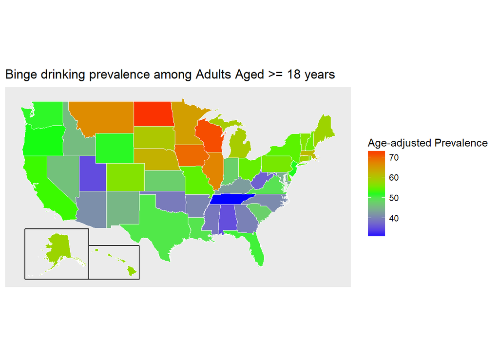

```r
p + fifty_states_inset_boxes()
```

The resulting map shows that binge drinking among adults is more prominent in the northern states. North Dakota is the most prominent, could it be the cold weather blues?

This data set is very complex and I have only scratched the surface of its potential. The procedures above can be replicated to map and compare other indicators.

This data set provides an excellent learning opportunity.